# 2. Algorithm Analysis

2. Algorithm Analysis

WU Xiaokun 吴晓堃

xkun.wu [at] gmail

2021/10/15

## Why analyzing algorithms?

Precise assessment leads to better understanding.

- correctness
  - theoretical proof
  - practical implementation
- efficiency
  - computable?
  - what design to choose?
  - any room for improvement?

We focus on the *efficiency* of algorithms now.

# Computational Tractability

## What is “Computational Tractability”

Loosely speaking, it’s used to delimitate whether a problem can be solved *in practice*.

- usually, relative to current state-of-the-art in computing.
- also, the contextual tolerance is often a key consideration.

**Intractable problem** maybe solvable in theory, but in practice any solution takes too many resources to be useful.

So **efficiency** is a synonym:

- resource requirements vs. computational power.

## Analytic Engine

> “By what course of calculation can these results be arrived at by the machine in the shortest time?” — Charles Babbage (1864)

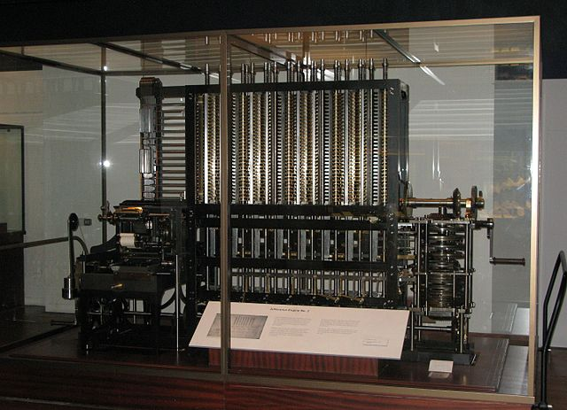

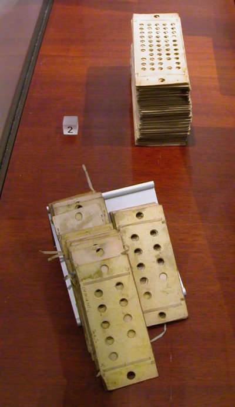

## Modern computing model

Consider a 64-bit system:

- Each **memory cell** stores a 64-bit integer.
- **Primitive operations**: arithmetic/logic operations, read/write memory, array indexing, following a pointer, conditional branch, etc.

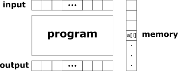

- **Time**: Number of primitive operations.
- **Space**: Number of memory cells utilized.

**Caveat**. At times, need more refined model (e.g., multiplying n-bit integers).

## How to define efficiency?

**Intuition**. When implemented, it runs quickly and uses few memory on real input instances.

- what platform?
- what is a “real” input instance?

We need a measure of algorithm *itself*, rather than external indicators.

Can we measure efficiency when input number is fixed?

- equal: count number of operations/cells required *per unit input*.
- counter-example: print $N$ number pairs vs. print $N$ numbers.

Better measure: How is the algorithm *scale* with problem size.

## Scalability

How resource requirements grow with increasing input size.

- The input has a natural “size” parameter $N$.
- Analyze running time mathematically as a function $T(N)$.

So we study and compare *growth of functions*.

- sampling: measure efficiency at a series of fixed input numbers.
- problem: algorithm behavior may depend on the order of input.

Need to use an *order-independent* statistics.

## Worst-Case Analysis

**Worst-Case Running Times**: largest possible running time.

- well-accepted but not perfect
  - only a few pathological inputs lead to bad performance
- hard to find an effective alternative

**Average-case analysis**: averaged over “random” instances.

- how a random input should be generated?
- more about how random inputs were generated than algorithm itself

Now consider and compare $T(N)$ on worst-cases

- also need a *baseline* implementation to mark the worst possibility.

## Brute-Force Search

**Brute-Force Search**: the most natural last-resort solution.

- no use in practice, but usually gives *exact analytical bounds*.
  - Stable matching problem: test all $n!$ perfect matchings for stability.

**Define efficient**: achieves qualitatively better worst-case performance, at an analytical level, than brute-force search.

- analytically shows algorithmic heuristics and problem structure
- what is “qualitatively better”?

Better scalability

- brute-force search usually grow exponentially fast
- intuitively, growth rate should be much slower

## Polynomial running time

**Desirable scaling property**. When input size *doubles*, algorithm slow down by at most some multiplicative constant factor $C$.

### An algorithm is poly-time if the above scaling property holds.

There exist constants $c > 0$ and $d > 0$ such that, for every input of size $N$, the running time of the algorithm is *bounded above* by $c N^d$ primitive computational steps.

- here $C = 2^d$, but why *doubles*?
- lower-degree polynomials grow slower

## Polynomial efficiency

**Def**. An algorithm is **efficient** if it has a polynomial running time.

- exactly characterize algorithm *itself*
  - platform-, instance-independent
- works in practice
  - break-through exponential barrier exposes crucial structure
  - when exist, always found moderately growing polynomials
  - becomes negatable: define **inefficiency**

Exceptions: galactic constants and/or huge exponents

- which is better: $20 n^{120}$ or $n^{1 + 0.02\ln n}$?

## Common polynomials

One million ($10^6$) high-level instructions per second.

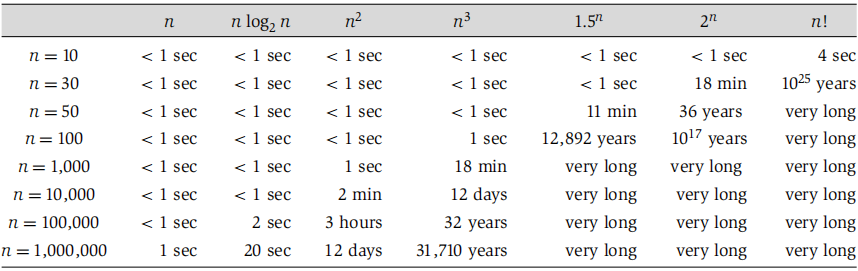

Notice the the huge difference between polynomial and exponential.

Now we found the way to compare growth of functions.

- compare different *categories* of growth rate

# Asymptotic Order of Growth

## Asymptotic analysis

Mathematically, asymptotic is used for describing *limiting* behavior.

- rigorous description of scalability: growth rate
- only a coarser level of granularity is necessary
  - Ex. $1.62n^2 + 3.5n + 8$ steps

Limits are natural *bounds* for analysis.

- upper bound, lower bound, exact bound.
- especially, *upper bound* for worst case

**Caution**. In CS, deal with discrete quantities.

- no such thing as “infinitesimal” in calculus.

## Asymptotic Upper Bounds (Big O)

### $T(n)$ is $O(f(n))$ (read as “$T(n)$ is order $f(n)$”)

- for sufficiently large $n$, function $T(n)$ is *bounded above* by a constant multiple of $f(n)$.
- $\exists c > 0, n_0 \ge 0: \forall n \ge n_0, T(n) \le c f(n)$.
  - $c$ cannot depend on $n$.

**Ex**. $T(n) = pn^2 + qn + r$:

- $T(n) = pn^2 + q^n + r \le pn^2 + qn^2 + rn^2 = (p + q + r)n^2$
  - $T(n) \le cn^2 \in O(n^2)$, where $c = p + q + r$.

## Big O notational abuses

**One-way “equality”**. $O(g(n))$ is a $set$ of functions.

- $f(n) \in O(g(n))$.
- but CSer often write $f(n) = O(g(n))$.

**Note**. $O(\cdot)$ expresses only *an* upper bound.

- $T(n) = pn^2 + q^n + r = O(n^3)$, since $n^2 \le n^3$.
  - but we cannot say $T(n) = sn^3$.
- in practice, we prefer “tightest” possible bound.

**Domain and Range**. $T$ and $f$ are real-valued functions.

- domain is typically natural numbers: $\mathbb{N} \to \mathbb{R}$.
- Sometimes extend to the reals: $\mathbb{R}_{\ge 0} \to \mathbb{R}$.
- Or restrict to a subset.

## Big O: properties

**Reflexivity**. $f$ is $O(f)$.

**Constants**. If $f$ is $O(g)$ and $c > 0$, then $c f$ is $O(g)$.

**Products**. If $f_1$ is $O(g_1)$ and $f_2$ is $O(g_2)$, then $f_1$ $f_2$ is $O(g_1 g_2)$.  
**Pf**.

- $∃ c_1 > 0 and n_1 \ge 0$ such that $0 \le f_1(n) \le c_1 g_1(n)$ for all $n \ge n_1$.
- $∃ c_2 > 0 and n_2 \ge 0$ such that $0 \le f_2(n) \le c_2 g_2(n)$ for all $n \ge n_2$.
- Then, $0 \le f_1(n) f_2(n) \le c_1 c_2 g_1(n) g_2(n)$ for all $n \ge \max\{ n_1, n_2\}$.

**Sums**. If $f_1$ is $O(g_1)$ and $f_2$ is $O(g_2)$, then $f_1 + f_2$ is $O(\max\{g_1, g_2\})$.

**Transitivity**. If $f$ is $O(g)$ and $g$ is $O(h)$, then $f$ is $O(h)$.

**Ex**. $f(n) = 5n^3 + 3n^2 + n + 1234$ is $O(n^3)$.

### $T(n)$ is $\Omega(f(n))$ (“$T(n) = \Omega(f(n))$”)

- for sufficiently large $n$, function $T(n)$ is *at least* a constant multiple of $f(n)$.
- $\exists \epsilon > 0, n_0 \ge 0: \forall n \ge n_0, T(n) \ge \epsilon f(n)$.
  - $c$ cannot depend on $n$.

**Ex**. $T(n) = 32n^2 + 17n + 1$

- $T(n)$ is both $\Omega(n^2)$ and $\Omega(n)$.
- $T(n)$ is not $\Omega(n^3)$.

### $T(n)$ is $\Theta(f(n))$ (“$T(n) = \Theta(f(n))$”)

- $T(n)$ is both $O(f(n))$ and also $\Omega(f(n))$.
- $\exists c_1 > 0, c_2 > 0, n_0 \ge 0: \forall n \ge n_0, 0 \le c_1 f(n) \le T(n) \le c_2 f(n)$.
  - $c_1, c_2$ cannot depend on $n$.

**Ex**. $T(n) = 32n^2 + 17n + 1$

**Compute**: closing *gap* between upper bound and lower bound

- design: *a* worst-case algorithm as upper bound
  - prove: no better possibilities
- justify asymptotically *tight* bound on worst-case running time

## Asymptotic bounds and limits

**Proposition**. If for some constant $0 < c < \infty$ $\lim_{n \to \infty} \frac{f(n)}{g(n)} = c$ then $f(n)$ is $\Theta(g(n))$.  
**Pf**.

- By definition of the limit, $\forall \epsilon > 0, \exists n_0: c - \epsilon \le \frac{f(n)}{g(n)} \le c + \epsilon, \forall n \ge n_0$.
- Choose $\epsilon = \frac{1}{2} c > 0$.
  - $\frac{1}{2} c g(n) \le f(n) \le \frac{3}{2} c g(n), \forall n \ge n_0$.

**Proposition**. If $\lim_{n \to \infty} \frac{f(n)}{g(n)} = 0$, then $f(n)$ is $O(g(n))$ but not $\Omega(g(n))$.

**Proposition**. If $\lim_{n \to \infty} \frac{f(n)}{g(n)} = \infty$, then $f(n)$ is $\Omega(g(n))$ but not $O(g(n))$.

## Asymptotic bounds for common functions

**Polynomials**. Let $f(n) = a_0 + a_1 n + \ldots + a_d n^d$ with $a_d > 0$. Then $f(n) = \Theta(n^d)$.  
**Pf**. $\lim_{n \to \infty} \frac{a_0 + a_1 n + \ldots + a_d n^d}{n^d} = a_d > 0$

**Logarithms**. $\log_a n = \Theta(\log_b n)$ for every $a > 1$ and every $b > 1$.  
**Pf**. $\frac{\log_a n}{\log_b n} = \frac{1}{\log_b a}$.

**Logarithms and polynomials**. $\log_a n = O(n^d)$ for every $a > 1$ and every $d > 0$.  
**Pf**. $\lim_{n \to \infty} \frac{\log_a n}{n^d} = 0$.

**Exponentials and polynomials**. $n^d = O(r^n)$ for every $r > 1$ and every $d > 0$.  
**Pf**. $\lim_{n \to \infty} \frac{n^d}{r^n} = 0$.

**Factorials**. $n! = 2^{\Theta(n \log n)}$.  
**Pf**. Stirling’s formula: $n! \thicksim \sqrt{2 \pi n} (\frac{n}{e})^n$.

## Big O notation with multiple variables

**Upper bounds**. $f(m, n) = O(g(m, n))$ if there exist constants $c > 0, m_0 \ge 0$, and $n_0 \ge 0$ such that $0 \le f(m, n) \le c g (m, n)$ for all $n \ge n_0, m \ge m_0$.

**Ex**. $f(m, n) = 32mn^2 + 17mn + 32n^3$.

- $f(m, n)$ is both $O(mn^2 + n^3)$ and $O(mn3)$.
- $f(m, n)$ is neither $O(n^3)$ nor $O(mn^2)$.
  - $f(m, n)$ is $O(n^3)$ if a precondition to the problem implies $m \le n$.

# Implement Gale–Shapley

## Goal: O(n^2) implementation

Algorithm terminates in at most $n^2$ iterations

- tightest worst-case bound: $O(n^2)$

The **goal** is $O(n^2)$ implementation

- each iteration takes constant time
  - ie., $O(1)$

## Recap: Gale–Shapley

INPUT: $M$, $W$, $R_m$, $R_w$  
INITIALIZE: $P = \varnothing$, mark $m \in M$ and $w \in W$ `free`  
WHILE some $m \in M$ is `free`

- $w$: highest on $R_m$ that $m$ has not yet proposed
- IF $w$ is `free`
  - Add $(m, w)$ to $P$
- ELSE IF $w$ prefers $m$ to current partner $m'$
  - Replace $(m', w)$ with $(m, w)$, set $m'$ `free`
- ELSE (Nothing happens.)

RETURN $P$

## Constant time operations

**Goal**: the following operations take constant time:

1. identify a `free` $m$.
2. given $m$, identify highest-ranked $w$ that $m$ not yet proposed.
3. given $w$, decide if is `matched`,
   - if so, identify current partner $m'$.
4. identify which ranks higher for $w$: $m$ or $m'$.

## Representation: next `free`

List $NF$ containing indices of $M$ (queue or stack also works)

- initialize to $n$ indices
  - initialization: $O(n)$ (= $O(n^2)$)
- take next free element: $O(1)$
- if replaced, push back: $O(1)$

## Representation: proposal

Reuse the preference list $R_m$, only check the head.

- head always has highest-ranked $w$: $O(1)$
- after taking out $w$, remove current head: $O(1)$

If $R_m$ is `constant`, maintain a pointer to next proposal.

- moving pointer to the next: $O(1)$

## Representation: matching

Index $M, W$: $\{1, 2, \ldots, n\}$.

**Matching**. Arrays $P_m, P_w$.

- if $m$ matched to $w$: $P_m(m) = w, P_w(w) = m$.
  - add/remove matching pair: $O(1)$
- initialize $P_m, P_w$ to $0$: `unmatched`.
  - identify whether `matched`, and to whom: $O(1)$
  - initialization: $O(n)$ (= $O(n^2)$)

## Representation: compare ranks

So far, operation 1-3 can be implemented in $O(1)$ time.

- now: identify which ranks higher for $w$: $m$ or $m'$.

**Naive implementation**: walk $R_w$

- $O(n)$ time to find $m$ and $m'$ on the list
  - breaks our $O(1)$ time goal

**Alternative**: trade space for time.

## Representation: compare ranks (cont.)

For each $w \in W$, maintain an array $I_w$ contains the inverse of $R_w$.

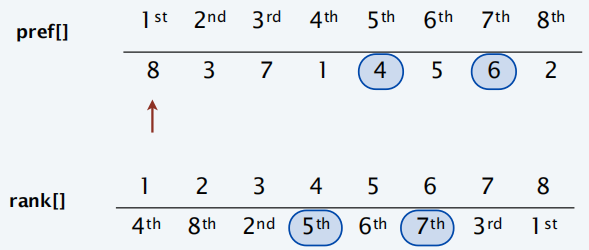

- for i = 1 to n: $I_w[R_w[i]] = i$
  - only need to compare $I_w[m]$ and $I_w[m']$: $O(1)$
  - $\Theta(n^2)$ time initialization.

## Gale–Shapley implementation: summary

**Theorem**. Can implement Gale–Shapley to run in $O(n^2)$ time.  
**Pf**.

- $\Theta(n^2)$ preprocessing time to create $n$ inverse ranking arrays.
- There are $O(n^2)$ proposals; processing each proposal takes $O(1)$ time.

**Theorem**. In the worst case, any algorithm to find a stable matching must query $R_m$ for $\Omega(n^2)$ times.  
[proof skipped.]

# Common Running Times

## Constant time

**Constant time**. Running time is $O(1)$.

- bounded by constant: not depend on input size $n$

**Examples**.

- Conditional branch.
- Arithmetic/logic operation.
- Declare/initialize a variable.
- Follow a link in a linked list.
- Access element $i$ in an array.
- Compare/exchange two elements in an array.

## Linear time

**Linear time**. Running time is $O(n)$.

- process input in a single pass,
  - spending constant time on each encountered item

**Computing the Maximum**.

**Merge two sorted lists**. Combine two *sorted* linked lists $A = a_1, a_2, \ldots, a_n$ and $B = b_1, b_2, \ldots, b_n$ into a sorted whole.

- at most $2n$ iterations

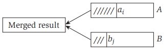

## Quiz: Target-Sum

**Target-Sum**. Given a *sorted* array of $n$ distinct integers and an integer $T$, find two that sum to exactly $T$?

Hint: move two indices from opposite side towards each other.

## Logarithmic time (Sublinear)

**Logarithmic time**. Running time is $O(\log n)$.

- splits input into two equal-sized pieces,
  - solves each piece recursively,
  - then combines two solutions in *constant time*.
- divide-and-conquer

**Search in a sorted array**. Given a sorted array $A$ of $n$ distinct integers and an integer $x$, find index of $x$ in array.  
**Binary search**.

- Invariant: If $x$ is in the array, then $x$ is in $A[lo .. hi]$.
- After $k$ iterations of `WHILE` loop, $(hi − lo + 1) \le n / 2^k \Rightarrow k \le 1 + \log_2 n$.

## Linearithmic time

**Linearithmic time**. Running time is $O(n \log n)$.

- splits input into two equal-sized pieces,
  - solves each piece recursively,
  - then combines two solutions in *linear time*.
- divide-and-conquer

**Sorting**. Given an array of $n$ elements, rearrange them in ascending order.

## Merge sort

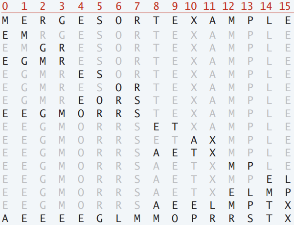

## Quadratic time

**Quadratic time**. Running time is $O(n^2)$.

- nested loops: search over all pairs of input items
  - spend constant time per pair.
- just the brute-force approach

**Closest pair of points**. Given a list of n points in the plane $(x_1, y_1), (x_2, y_2), \ldots, (x_n, y_n)$, find the pair that is closest to each other.  
**O(n^2) algorithm**. Enumerate all pairs of points (with $i < j$).

**Remark**. $\Omega(n^2)$ seems inevitable, but this is just an illusion.

## Cubic time

**Cubic time**. Running time is $O(n^3)$.

- nested loops: search over all subsets of size 3.
- almost the borderline of practical

**3-SUM**. Given an array of $n$ distinct integers, find three that sum to $0$.  
**O(n^3) algorithm**. Enumerate all triples (with $i < j < k$).

**Remark**. $\Omega(n^3)$ seems inevitable, but $O(n^2)$ is not hard.

## Polynomial time

**Polynomial time**. Running time is $O(n^k)$ for some constant $k > 0$.

- nested loops: search over all subsets of size k.
- computationally too hard to be practical

**Independent set of size $k$**. Given a graph, find $k$ nodes such that no two are joined by an edge.  
**$O(n^k)$ algorithm**. Enumerate all subsets of $k$ nodes.

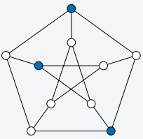

- Check whether $S$ is an independent set of size $k$ takes $O(k^2)$ time.
- Number of $k$-element subsets = ${n \choose k} = \frac{n(n-1)(n-2)\cdots(n-k+1)}{k(k-1)(k-2)\cdots1} \le \frac{n^k}{k!}$
- in total: $O(k^2 n^k / k!) = O(n^k)$

## Exponential time

**Exponential time**. Running time is $O(2^{n^k})$ for some constant $k > 0$.

- combinatorial: enumerate all subsets

**Independent set**. Given a graph, find independent set of max cardinality.  
**$O(n^2 2^n)$ algorithm**. Enumerate all subsets of $n$ elements.

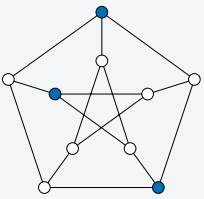

- total number of subsets: $2^n$

## Quiz: Exponential time

Which is an equivalent definition of exponential time?

- $O(2^n)$.
- $O(2^{cn})$ for some constant $c > 0$.
- Both.
- Neither.

Neither: take the limit of division.

# Recap: Priority Queue

## Priority

**Primary goal**. seek algorithms that improve qualitatively on brute-force search.

- use polynomial-time solvability as concrete formulation
- more complex data structures lead to better performance

**Priority Queue**. Each element has a priority value.

- properties
  - always take out the highest-priority element
  - $O(\log n)$ time per operation.
- should be familiar after taking *Data Structure* & *Operating System*.

## Heap

Maintain elements in sorted order of keys.

- alternatives: sorted array, sorted doubly linked list

Conceptually, think heap as *balanced binary tree*

**Heap order**: For every element $v$, at a node $i$, the element $w$ at $i$’s parent satisfies $key(w) \le key(v)$.

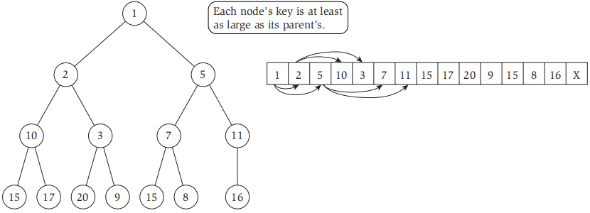

## Heap Operations

**Heapify-up**: fixing the heap by pushing the damaged part upward.

- insert a new element in a heap of $n$ elements in $O(\log n)$ time.

**Heapify-down**: proceeds down the tree recursively.

- delete a new element in a heap of $n$ elements in $O(\log n)$ time.

## Implementing Priority Queues

- StartHeap(N): $O(n)$
- Insert(H, v): $O(\log n)$
- FindMin(H): $O(1)$
- Delete(H, i): $O(\log n)$
- ExtractMin(H): $O(\log n)$